# Statistical modeling in R

Statistical Programming with R

## Statistical modeling in R

## This Lecture:

- Models in R - mainly the classic linear model, logistic regression in the practicals
- Checking assuptions
- Model fit & comparison
- Predictions

## I use the following packages in this lecture

```r
library(dplyr)
library(Ecdat)    #for the Benefits data
library(ggplot2)
```

## The linear model

## The linear model

The function `lm()` is a base function in `R` and allows you to pose a variety of linear models.

```r
args(lm)
```

```
## function (formula, data, subset, weights, na.action, method = "qr",
##     model = TRUE, x = FALSE, y = FALSE, qr = TRUE, singular.ok = TRUE,
##     contrasts = NULL, offset, ...)
## NULL
```

If we want to know what these arguments do we can ask R:

```r
?lm
```

This will open a help page on the `lm()` function.

## Benefits data

Unemployment of blue collar workers:

Column `stateur`:

- state unemployment rate (in %)

Column `tenure`:

- years of tenure in jobs lost

Column `age`:

- age in years

Column `joblost`:

- reason for loss of job (position abolished, seasonal job, not performing well enough, other)

## Linear regression

Linear regression model \[ y_i=\alpha+\beta{x}_i+\varepsilon_i \]

Assumptions:

- \(y_i\) conditionally normal with mean \(\mu_i=\alpha+\beta{x}_i\)
- \(\varepsilon_i\) are \(i.i.d.\) with mean 0 and (constant) variance \(\sigma^2\)

## Continuous predictors

To obtain a linear model with just main effects for `tenure` and `age`, we formulate \(stateur\sim tenure + age\)

```r
fit <- lm( stateur ~ tenure + age , data = Benefits)
fit
```

```
##
## Call:
## lm(formula = stateur ~ tenure + age, data = Benefits)
##
## Coefficients:
## (Intercept)       tenure          age
##     7.91128      0.02072     -0.01433
```

## Continuous predictors: more detail

```r
fit %>% summary
```

```
##
## Call:
## lm(formula = stateur ~ tenure + age, data = Benefits)
##
## Residuals:
##     Min      1Q  Median      3Q     Max
## -5.3165 -1.8217 -0.3982  1.4691 10.7142
##
## Coefficients:
##              Estimate Std. Error t value Pr(>|t|)
## (Intercept)  7.911283   0.130724  60.519  < 2e-16 ***
## tenure       0.020721   0.006517   3.179 0.001485 **
## age         -0.014327   0.003861  -3.711 0.000209 ***
## ---
## Signif. codes:  0 '***' 0.001 '**' 0.01 '*' 0.05 '.' 0.1 ' ' 1
##
## Residual standard error: 2.497 on 4874 degrees of freedom
## Multiple R-squared:  0.003322,   Adjusted R-squared:  0.002913
## F-statistic: 8.122 on 2 and 4874 DF,  p-value: 0.0003009
```

## Components of the linear model

```r
names(fit) # the names of the list with output objects
```

```
##  [1] "coefficients"  "residuals"     "effects"       "rank"
##  [5] "fitted.values" "assign"        "qr"            "df.residual"
##  [9] "xlevels"       "call"          "terms"         "model"
```

```r
fit$coef  # show the estimated coefficients
```

```
## (Intercept)      tenure         age
##  7.91128302  0.02072099 -0.01432655
```

```r
coef(fit) # alternative
```

## Continuous predictors: interaction effects

To obtain a linear model with an interaction effect for `tenure` and `age`, we formulate \(stateur\sim tenure * age\)

```r
fit <- lm( stateur ~ tenure * age, data = Benefits)
```

Equivalent

```r
fit <- Benefits %$% lm(stateur ~ tenure + age + tenure:age)
```

## Continuous predictors: interaction effects

```r
fit
```

```
##
## Call:
## lm(formula = stateur ~ tenure * age, data = Benefits)
##
## Coefficients:
## (Intercept)       tenure          age   tenure:age
##    7.686119     0.076781    -0.009180    -0.001174
```

## and with more detail

```r
fit %>% summary
```

```
##
## Call:
## lm(formula = stateur ~ tenure * age, data = Benefits)
##
## Residuals:
##     Min      1Q  Median      3Q     Max
## -5.4060 -1.8214 -0.3735  1.4856 10.6933
##
## Coefficients:
##               Estimate Std. Error t value Pr(>|t|)
## (Intercept)  7.6861194  0.1708825  44.979  < 2e-16 ***
## tenure       0.0767806  0.0281768   2.725  0.00645 **
## age         -0.0091803  0.0046074  -1.992  0.04637 *
## tenure:age  -0.0011741  0.0005742  -2.045  0.04091 *
## ---
## Signif. codes:  0 '***' 0.001 '**' 0.01 '*' 0.05 '.' 0.1 ' ' 1
##
## Residual standard error: 2.496 on 4873 degrees of freedom
## Multiple R-squared:  0.004176,   Adjusted R-squared:  0.003563
## F-statistic: 6.812 on 3 and 4873 DF,  p-value: 0.0001405
```

## Categorical predictors in the linear model

If a categorical variable is entered into function `lm()`, it is automatically converted to a dummy set in `R`. The first level is always taken as the reference category. If we want another reference category we can use the function `relevel()`.

```r
Benefits %>% count( joblost )
```

```
##              joblost    n
## 1              other 1976
## 2 position_abolished  402
## 3 seasonal_job_ended  177
## 4         slack_work 2322
```

```r
fit_c <- lm(stateur ~ joblost, data=Benefits)
```

## and again with more detail

```r
fit_c %>% summary
```

```
##
## Call:
## lm(formula = stateur ~ joblost, data = Benefits)
##
## Residuals:
##     Min      1Q  Median      3Q     Max
## -5.4848 -1.8062 -0.4062  1.5152 10.6806
##
## Coefficients:
##                           Estimate Std. Error t value Pr(>|t|)
## (Intercept)                7.36412    0.05615 131.161  < 2e-16 ***
## joblostposition_abolished -0.04472    0.13656  -0.327    0.743
## joblostseasonal_job_ended -0.05790    0.19582  -0.296    0.767
## joblostslack_work          0.32072    0.07639   4.199 2.73e-05 ***
## ---
## Signif. codes:  0 '***' 0.001 '**' 0.01 '*' 0.05 '.' 0.1 ' ' 1
##
## Residual standard error: 2.496 on 4873 degrees of freedom
## Multiple R-squared:  0.004427,   Adjusted R-squared:  0.003814
## F-statistic: 7.223 on 3 and 4873 DF,  p-value: 7.81e-05
```

## Checking assumptions

## Linearity

```r
Benefits %>%
  ggplot(aes(tenure, stateur)) +
  geom_point() +
  geom_smooth(method = "loess", col = "blue") +
  geom_smooth(method = "lm", col = "orange")
```

## Linearity

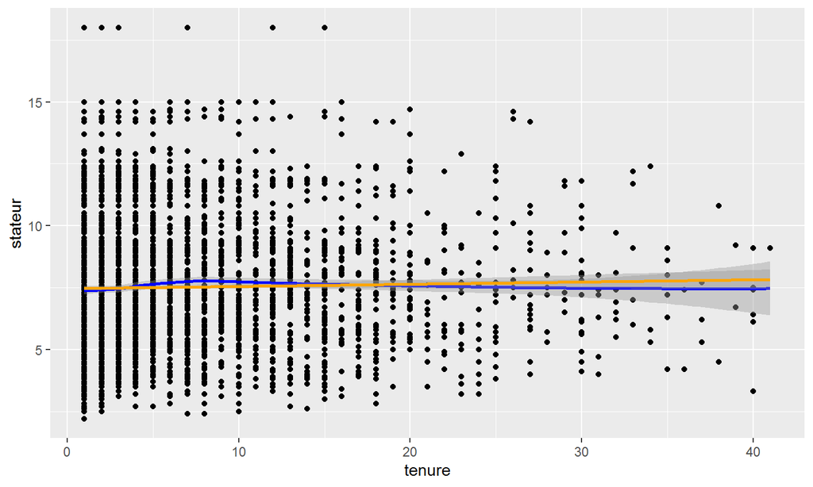

The loess curve suggests slight non-linearity

## Adding a squared term

```r
lm(stateur ~ tenure + I(tenure^2), data=Benefits)
```

```
##
## Call:
## lm(formula = stateur ~ tenure + I(tenure^2), data = Benefits)
##
## Coefficients:
## (Intercept)       tenure  I(tenure^2)
##    7.364839     0.042713    -0.001339
```

## Constant error variance?

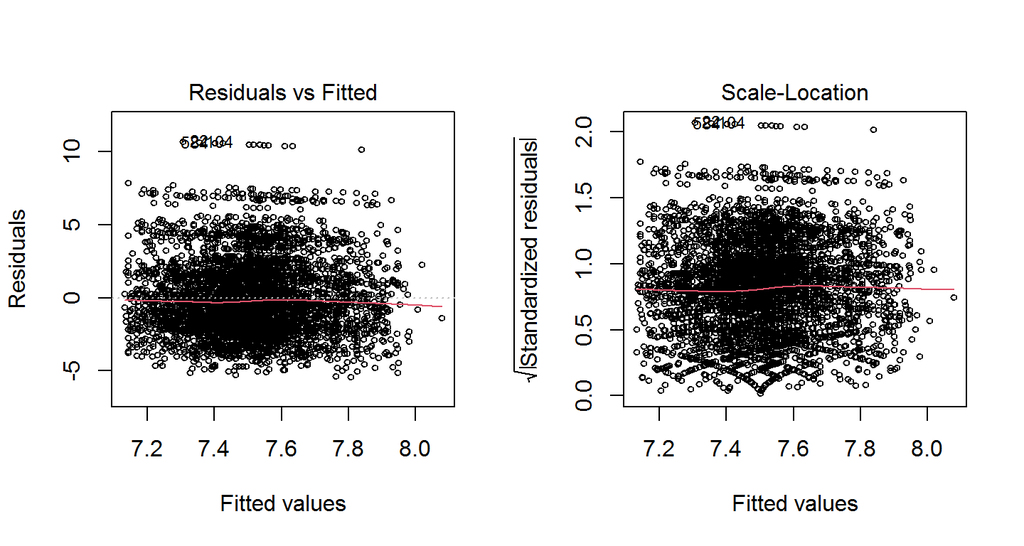

```r
par(mfrow = c(1, 2))
fit %>%
  plot(which = c(1, 3), cex = .6)
```

## Normality of errors

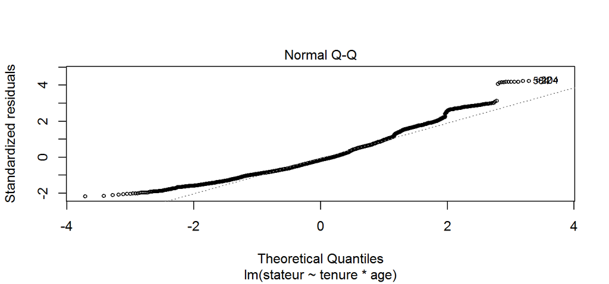

```r
fit %>%
  plot(which = 2, cex = .6)
```

The QQplot shows divergence from normality at the tails

## Outliers and influential cases

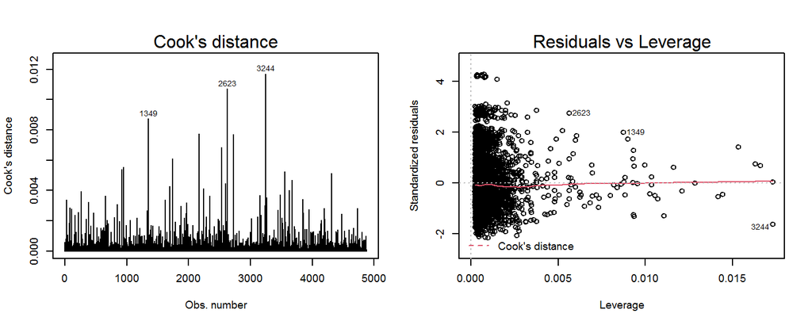

```r
par(mfrow = c(1, 2), cex = .6)
fit %>% plot(which = c(4, 5))
```

There are quite some cases with \(|e_z|>2\) (right plot). There are no cases with Cook’s Distance \(>1\), but some cases stand out.

## Model fit & comparison

## AIC and BIC

Akaike’s *An Information Criterion*

```r
fit %>%
  AIC()
```

```
## [1] 22768.67
```

and *Bayesian Information Criterion*

```r
fit %>%
  BIC()
```

```
## [1] 22801.13
```

## R-squared

```r
summary(fit)$r.squared
```

```
## [1] 0.004176409
```

```r
summary(fit)$adj.r.squared
```

```
## [1] 0.003563343
```

## Prediction

## Fitted values

```r
y_hat <-
  fit %>%
  fitted.values()
```

```r
(y_hat - Benefits$stateur)[1:12]
```

```
##          1          2          3          4          5          6          7
##  3.1404839 -2.9600636  0.6853898  1.7052117  0.9212021 -0.2313798  1.8184910
##          8          9         10         11         12
##  1.7861893 -0.2420797  1.4419110  0.2925939 -2.5618179
```

## Predict new values

```r
new.data <- data.frame(tenure = 1:10, age=20:29)
predict.lm(fit, newdata = new.data)
```

```
##        1        2        3        4        5        6        7        8
## 7.555810 7.597579 7.637000 7.674073 7.708797 7.741173 7.771201 7.798881
##        9       10
## 7.824212 7.847195
```

## Prediction intervals

```r
predict(fit, interval = "prediction") %>% head()
```

```
##        fit      lwr      upr
## 1 7.640484 2.743470 12.53750
## 2 7.539936 2.645295 12.43458
## 3 7.885390 2.986604 12.78418
## 4 7.505212 2.609303 12.40112
## 5 7.421202 2.526766 12.31564
## 6 7.268620 2.372745 12.16450
```

## Some other modeling devices in `R`

- `lm()`: linear modeling
- `glm()`: generalized linear modeling
- `gamlss::gamlss`: generalized additive models (for location, scale and shape)
- `lme4::lmer`: linear mixed effect models
- `lme4::glmer`: generalized linear mixed effect models
- `lme4::nlmer`: non-linear mixed effect models

## Honorary mention: broom

If you want the output of regression models to be nice and tidy for further work, the `broom` package is your friend

```r
fit %>% broom::tidy()
```

```
## # A tibble: 4 x 5
##   term        estimate std.error statistic p.value
##   <chr>          <dbl>     <dbl>     <dbl>   <dbl>
## 1 (Intercept)  7.69     0.171        45.0  0
## 2 tenure       0.0768   0.0282        2.72 0.00645
## 3 age         -0.00918  0.00461      -1.99 0.0464
## 4 tenure:age  -0.00117  0.000574     -2.04 0.0409
```

## Honorary mention: broom

```r
fit %>% broom::glance()
```

```
## # A tibble: 1 x 12
##   r.squared adj.r.squared sigma statistic  p.value    df  logLik    AIC    BIC
##       <dbl>         <dbl> <dbl>     <dbl>    <dbl> <dbl>   <dbl>  <dbl>  <dbl>
## 1   0.00418       0.00356  2.50      6.81 0.000140     3 -11379. 22769. 22801.
## # ... with 3 more variables: deviance <dbl>, df.residual <int>, nobs <int>
```

## Honorary mention: broom

```r
fit %>% broom::augment()
```

```
## # A tibble: 4,877 x 9
##    stateur tenure   age .fitted .resid     .hat .sigma    .cooksd .std.resid
##      <dbl>  <int> <int>   <dbl>  <dbl>    <dbl>  <dbl>      <dbl>      <dbl>
##  1     4.5     21    49    7.64 -3.14  0.00143    2.50 0.000567      -1.26
##  2    10.5      2    26    7.54  2.96  0.000458   2.50 0.000161       1.19
##  3     7.2     19    40    7.89 -0.685 0.00215    2.50 0.0000408     -0.275
##  4     5.8     17    51    7.51 -1.71  0.000977   2.50 0.000114      -0.683
##  5     6.5      1    33    7.42 -0.921 0.000375   2.50 0.0000128     -0.369
##  6     7.5      3    51    7.27  0.231 0.000963   2.50 0.00000207     0.0927
##  7     5.8      5    30    7.62 -1.82  0.000325   2.50 0.0000431     -0.729
##  8     5.8      3    26    7.59 -1.79  0.000401   2.50 0.0000514     -0.716
##  9     7.7     20    54    7.46  0.242 0.00170    2.50 0.00000402     0.0971
## 10     6        1    31    7.44 -1.44  0.000403   2.50 0.0000337     -0.578
## # ... with 4,867 more rows
```